# Barplots

Mon Oct 10, 2016

## 5NG

Today:

1. Scatterplot AKA bivariate plot
2. Linegraph
3. Boxplot
4. Histogram
5. **Barplot AKA barchart AKA bargraph**

## Exercise

Say we have the following piecharts represent the polling from a local election with five candidates (1-5) at three different time points A, B, an C:

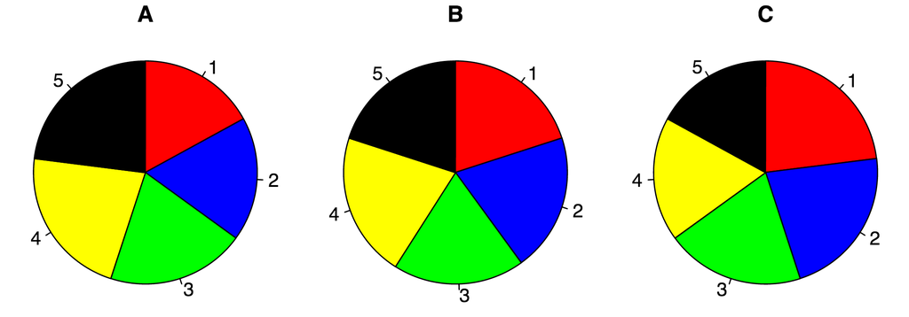

Answer the following questions:

- In the first race, is candidate 5 doing better than candidate 4?
- Who did better between time A and time B, candidate 2 or candidate 4?

## Exercise

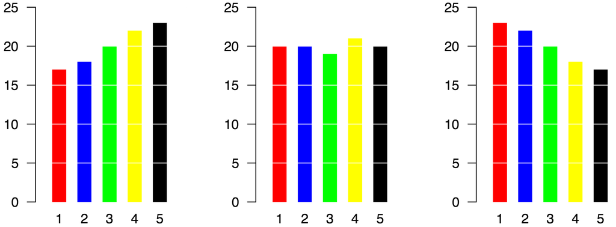

## Barplots

- Barplots display information about a single **categorical** variable as the `x` aesthetic.
- The y-axis displays notions of **relative frequency** i.e. which values occur more than others.
- This is not an **explicit** variable in the data set, but rather is either
  - Computed internally
  - Computed manually by yourself

## Barplots

- `geom_bar()` is the trickiest of the 5NG in `ggplot2`, hence me presenting it last
- Correspondingly, we'll use it in limited capacity in this class and no need to open can of worms.
- If, however, you are feeling adventurous and want to open the can, feel free to ask me anyway!

## Barplots

Recall from Lec05 Slide 16, we displayed

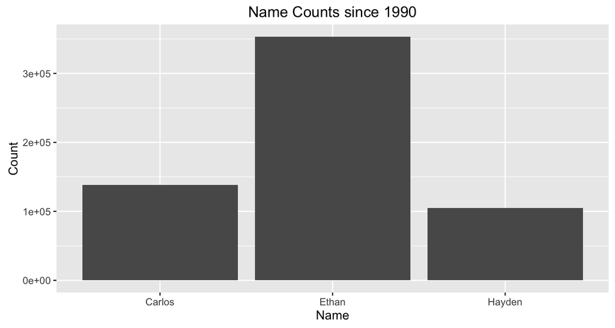

## Chief Difficulty with Barplots

There are two different ways to input the data:

- Where the counts **are not** pre-computed (today)
- Where the counts **are** pre-computed

## Example

Counts **are not** pre-computed:

| Row Number | name |
| --- | --- |
| 1 | Albert |
| 2 | Albert |
| 3 | Albert |
| 4 | Virginia |
| 5 | Virginia |

## Example

Counts **are** pre-computed in variable `n`. So `n` becomes a `y` aesthetic variable!

| name | n |
| --- | --- |
| Albert | 3 |
| Virginia | 2 |